# Correlation Analysis & Predictive Model of the Average House Price in Canada

Shayla Tran

# Introduction

In this project, we analyze the Canadian housing market by studying how different economic factors affect house prices from 2013 to 2021. We focus on seven key economic indicators and use correlation analysis to understand their relationship with housing prices. To predict house prices for the year 2022, we apply two predictive modeling techniques: LASSO (Least Absolute Shrinkage and Selection Operator) and Random Forests.

# Economic Factors

The economic factors chosen for this study are all based in Canada and are the following :

##### 1. Consumer price index (CPI)

A measure that tracks the average price change over time for a fixed basket of goods and services. Presented as an index value.

[Data source](https://www150.statcan.gc.ca/t1/tbl1/en/tv.action?pid=1810000501)

##### 2. Employment rate

The percentage of the entire Canadian population that is employed. Includes individuals of all education levels from primary school to graduate degrees.

Data source

##### 3. Gross domestic product (GDP) at basic prices

The total monetary value of all finished goods and services produced within a country’s borders in a specific time period. The units are in CAD million dollars

[Data source](https://www150.statcan.gc.ca/t1/tbl1/en/tv.action?pid=3610040101)

##### 4. Housing investment

The total monetary value of all investments in residential construction for all dwelling types, including private and social housing. The units are in CAD million dollars.

[Data source](https://www150.statcan.gc.ca/t1/tbl1/en/tv.action?pid=3610067701)

##### 5. Median income

The median total income for Canadian citizens based on both sexes and all age groups. The units are in CAD dollars.

[Data source](https://www150.statcan.gc.ca/t1/tbl1/en/tv.action?pid=1110000801)

##### 6. Mortgage interest rate

The average interest rate for new and existing lending, for both insured and uninsured mortgages. This data also includes both variable and fixed rates. Presented as a percentage.

[Data source](https://www150.statcan.gc.ca/t1/tbl1/en/tv.action?pid=1010000601)

##### 7. Population

The total annual population of Canada, including all age groups and both sexes. Presented as the number of persons.

[Data source](https://www150.statcan.gc.ca/t1/tbl1/en/tv.action?pid=1710000501)

These factors are known to be possibly associated with the fluctuations of the housing market (see Ref. 1 and Ref. 2). We additionally have the [average price of a house in Canada from 2013 to 2021](https://www.crea.ca/housing-market-stats/canadian-housing-market-stats/) to compare with and to use to train our models.

[Reference 1](https://www.moneysense.ca/spend/real-estate/whats-affecting-canadas-real-estate-and-housing-market/)

[Reference 2](https://www.cmhc-schl.gc.ca/professionals/housing-markets-data-and-research/housing-data/data-tables/housing-market-indicators)

We’ll start by loading in the `.csv` files for each datasest. The dataframes will include the years from 2013 to 2021 and the value.

```r
# Loading in the libraries
library(tidyverse)
library(ggplot2)
library(gridExtra)
library(corrplot)
library(randomForest)
library(glmnet)
```

```r
# Reading in the .csv files and alter tables
cpi <- read.csv("raw\ data/consumerpriceindex.csv") %>%
  filter(REF_DATE >= 2013, REF_DATE <= 2021) %>%          # Filter for years 2013 - 2021
  filter(Products.and.product.groups == 'All-items') %>%  # Filter for 'All-items' only
  rename(YEAR = REF_DATE, CPI_index = VALUE) %>%          # Rename columns
  select(YEAR, CPI_index)                                     # Select necessary columns

emp <- read.csv("raw\ data/employment.csv") %>%
  filter(REF_DATE >= 2013, REF_DATE <= 2021) %>%
  filter(Educational.attainment == "Total, all education levels") %>%
  rename(YEAR = REF_DATE, EMP_percentage = VALUE) %>%
  select(YEAR, EMP_percentage)

gdp <- read.csv("raw\ data/gdp.csv") %>%
  filter(REF_DATE >= 2013, REF_DATE <= 2021) %>%
  filter(North.American.Industry.Classification.System..NAICS. == 'All industries [T001]') %>%
  rename(YEAR = REF_DATE, GDP = VALUE) %>%
  group_by(YEAR) %>%
  summarize(GDP = mean(GDP)) # Calculate average GDP for each year

hi <- read.csv("raw\ data/housinginvestment.csv") %>%
  filter(REF_DATE >= 2013, REF_DATE <= 2021) %>%
  filter(Institutional.sector == 'Total economy') %>%
  rename(YEAR = REF_DATE, House_Investment = VALUE) %>%
  select(YEAR, House_Investment) # In millions

income <- read.csv("raw\ data/income.csv") %>%
  filter(REF_DATE >= 2013, REF_DATE <= 2021) %>%
  filter(Persons.with.income == "Median total income") %>%
  rename(YEAR = REF_DATE, Median_Salary = VALUE) %>%
  select(YEAR, Median_Salary)

intrate <- read.csv("raw data/interestrate.csv") %>%
  mutate(YEAR = as.integer(substr(REF_DATE, 1, 4))) %>%  # Extract year from REF_DATE and convert to integer
  filter(YEAR >= 2013, YEAR <= 2021) %>%                 # Filter for years 2013 - 2021
  filter(Components %in% c('Total, funds advanced, residential mortgages, insured',
                           'Total, funds advanced, residential mortgages, uninsured',
                           'Total, outstanding balances, residential mortgages, insured',
                           'Total, outstanding balances, residential mortgages, uninsured')) %>%
                           # Filter for chosen components
  group_by(YEAR) %>%
  summarize(Interest_Rate = mean(VALUE[Unit.of.measure == 'Interest rate'], na.rm = TRUE)) %>%
  # Compute the mean interest rate across components per year
  ungroup()

pop <- read.csv("raw\ data/population.csv") %>%
  filter(REF_DATE >= 2013, REF_DATE <= 2021) %>%
  filter(Age.group == 'All ages') %>%
  rename(YEAR = REF_DATE, Population = VALUE) %>%
  select(YEAR, Population)

avgprice <- read.csv("raw\ data/avgprice.csv")
colnames(avgprice) <- trimws(colnames(avgprice)) # Clean the column names to remove leading/trailing whitespaces
avgprice <- avgprice %>%
  mutate(YEAR = year(dmy(paste0("01-", Date))),  # Parse 'Date' and extract the year
         AVG_HousePrice = as.numeric(`Average.`)) %>%  # Convert 'Average.' to numeric
  filter(YEAR >= 2013, YEAR <= 2021) %>%  # Filter for years 2013 - 2021
  group_by(YEAR) %>%  # Group by YEAR
  summarize(AVG_HousePrice = mean(AVG_HousePrice, na.rm = TRUE)) %>% # Calculate average price per year
  ungroup()
```

# Scatterplots

Generating a collection of scatterplots to visualize the data of all the eight datasets.

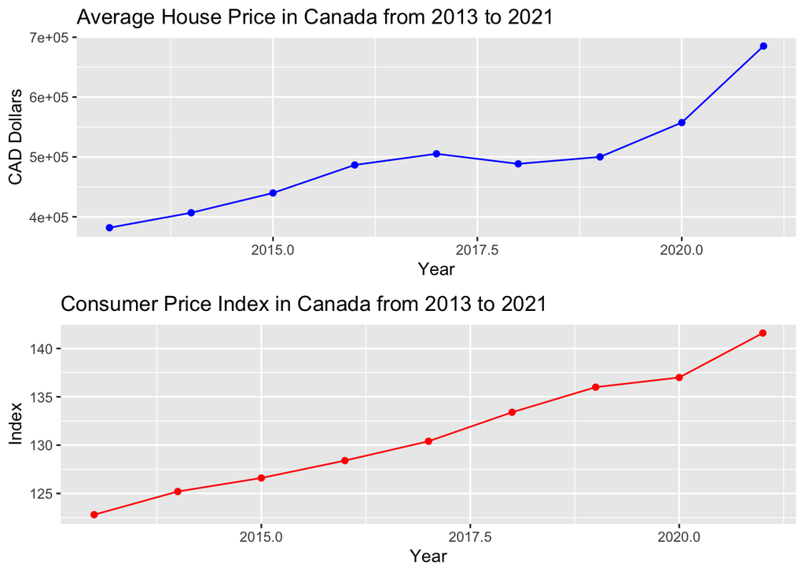

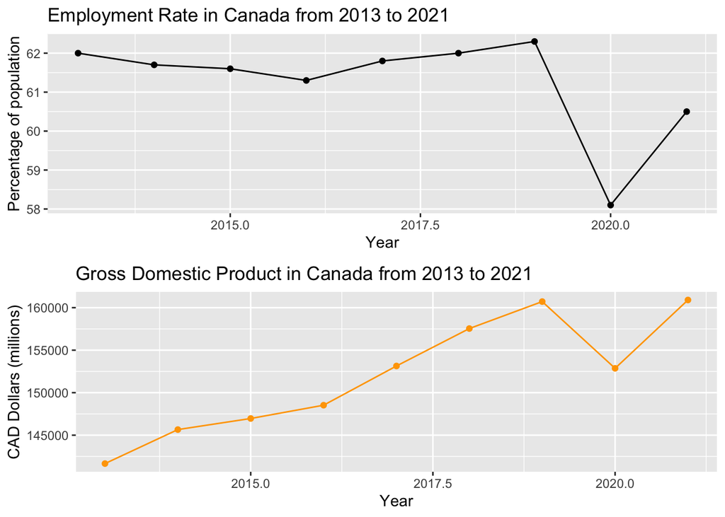

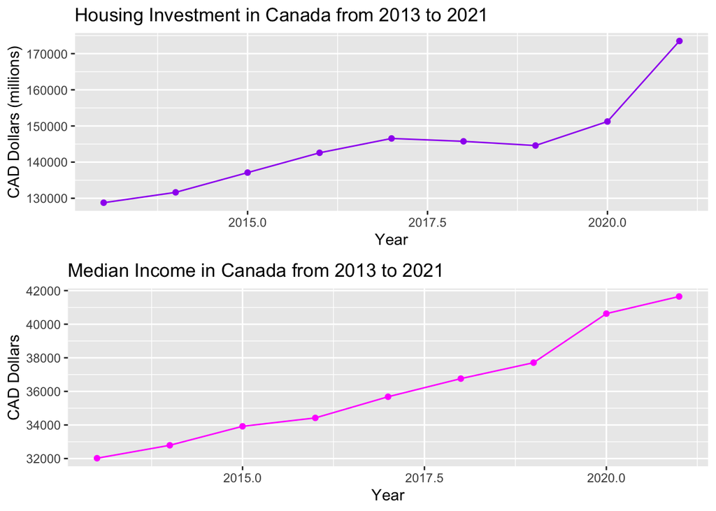

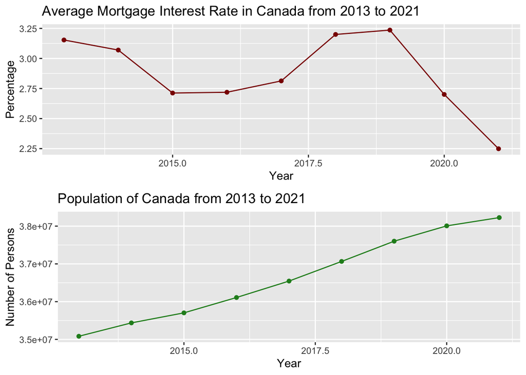

```r
# Generating scatterplot for each data frame (for all the economic factors)

plot.cpi <- ggplot(cpi, aes(x = YEAR, y = CPI_index)) + geom_point(colour = "red") + geom_line(colour = "red") + ggtitle("Consumer Price Index in Canada from 2013 to 2021") + xlab("Year") + ylab("Index")

plot.hi <- ggplot(hi, aes(x = YEAR, y = House_Investment)) + geom_point(colour = "purple") + geom_line(colour = "purple") + ggtitle("Housing Investment in Canada from 2013 to 2021") + xlab("Year") + ylab("CAD Dollars (millions)")

plot.gdp <- ggplot(gdp, aes(x = YEAR, y = GDP)) + geom_point(colour = "orange") + geom_line(colour = "orange") + ggtitle("Gross Domestic Product in Canada from 2013 to 2021") + xlab("Year") + ylab("CAD Dollars (millions)")

plot.income <- ggplot(income, aes(x = YEAR, y = Median_Salary)) + geom_point(colour = "magenta") + geom_line(colour = "magenta") + ggtitle("Median Income in Canada from 2013 to 2021") + xlab("Year") + ylab("CAD Dollars")

plot.intrate <- ggplot(intrate, aes(x = YEAR, y = Interest_Rate)) + geom_point(colour = "darkred") + geom_line(colour = "darkred") + ggtitle("Average Mortgage Interest Rate in Canada from 2013 to 2021") + xlab("Year") + ylab("Percentage")

plot.pop <- ggplot(pop, aes(x = YEAR, y = Population)) + geom_point(colour = "forestgreen") + geom_line(colour = "forestgreen") + ggtitle("Population of Canada from 2013 to 2021") + xlab("Year") + ylab("Number of Persons")

plot.avgprice <- ggplot(avgprice, aes(x = YEAR, y = AVG_HousePrice)) + geom_point(colour = "blue") + geom_line(colour = "blue") + ggtitle("Average House Price in Canada from 2013 to 2021") + xlab("Year") + ylab("CAD Dollars")

plot.emp <- ggplot(emp, aes(x = YEAR, y = EMP_percentage)) + geom_point() + geom_line() + ggtitle("Employment Rate in Canada from 2013 to 2021") + xlab("Year") + ylab("Percentage of population")
```

# Correlation Analysis using `corrplot`

This correlation analysis investigates the relationship between key economic factors and average house prices in Canada. By merging datasets on variables like CPI, GDP, employment, and interest rates, we aim to identify how these elements interact with housing prices. The resulting correlation matrix offers insights into which economic indicators most significantly influence the housing market, aiding in understanding market dynamics and informing decision-making in real estate and economic policy.

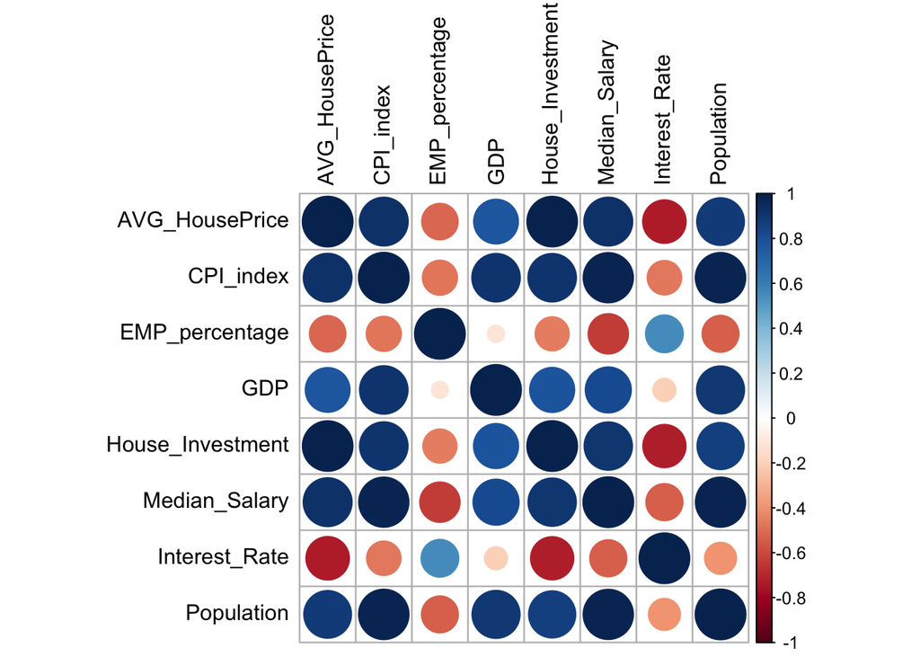

```r
# Merge all the dataframes into one
merged.df <- reduce(list(avgprice, cpi, emp, gdp, hi, income, intrate, pop), left_join, by = "YEAR")

# Calculate correlation
cor_matrix <- cor(merged.df[, -1])  # Exclude the first column if it is 'Year'
corrplot(cor_matrix, method = "circle", tl.col = "black", tl.cex = 1)
```

#### Interpretation

We can use this result to direct variable selection when building a model and choosing features that are strongly correlated with the average house price. For simplicity, the results from this analysis will not be considered for model building but demonstrates how a correlation analysis can be a stepping stone into variable selection.

# Building A Predictive Model using Regression Models

Two models are developed using Random Forests and LASSO regression to predict Canadian house prices, trained on combined data from 2013 to 2021. For 2022, three scenarios are crafted in a synthetic dataset to reflect possible economic conditions, using the data trends from 2021. The models’ accuracy was tested with cross-validation techniques: LOOCV for LASSO and OOB for Random Forests, ensuring reliable predictions with the Mean Squared Error (MSE) as the accuracy metric.

##### The 2022 Dataset

*This approach is very generalized and does not represent the actual economic trends of 2022. This is for demonstration purposes to test and use the model to make predictions on a set of variables only. Due to the limited available data, the actual predictor values for the year 2022 were not attainable.*

```r
# The fabricated 2022 data frames for the 3 scenarios
improving_factors <- c(1.02, 1.03, 1.04, 1.05, 1.04, 1.03, -0.05, 1.02)
worsening_factors <- c(1.01, 0.97, 0.96, 0.95, 0.97, 0.96, 0.10, 0.99)
stable_factors <- c(1.01, 0.99, 1.01, 1.01, 1.01, 1.01, 0.99, 1.01)

# Apply the changes to the last known year's data
synthetic_2022 <- rbind(
  "Improving" = round(merged.df[9, 2:9] * improving_factors, 2),
  "Worsening" = round(merged.df[9, 2:9] * worsening_factors, 2),
  "Stable" = round(merged.df[9, 2:9] * stable_factors, 2)
)

# Add the YEAR column
synthetic_2022$YEAR <- 2022
synthetic_2022
```

```
##           AVG_HousePrice CPI_index EMP_percentage      GDP House_Investment
## Improving       698906.2    145.85          62.92 168947.5         180443.1
## Worsening       692054.2    137.35          58.08 152857.2         168297.9
## Stable          692054.2    140.18          61.11 162511.4         175238.0
##           Median_Salary Interest_Rate Population YEAR
## Improving       42899.5         -0.11   38991028 2022
## Worsening       39984.0          0.22   37844233 2022
## Stable          42066.5          2.23   38608763 2022
```

### LASSO

Executes a LASSO regression to predict average house prices, using leave-one-out cross-validation (LOOCV) for model accuracy. The best lambda value is identified that minimizes the mean squared error (MSE), then the final model is fit using this lambda. The final model predicts house prices for 2022 under the three economic scenarios.

```r
lasso.hp <- cv.glmnet(model.matrix(AVG_HousePrice ~ . - YEAR, data=merged.df), alpha = 1, merged.df$AVG_HousePrice, nfolds=nrow(merged.df)) # Perform LOOCV by setting folds to number of rows in the merged dataframe
```

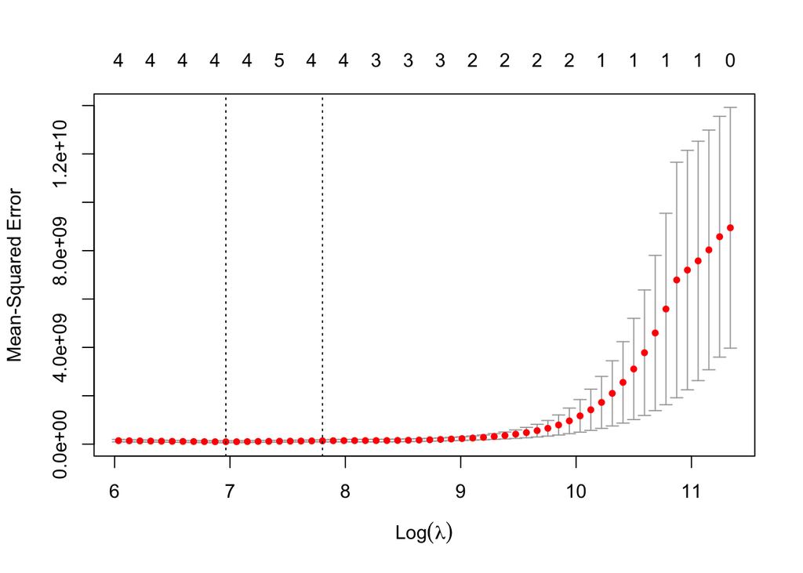

```r
plot(lasso.hp)
```

```r
# Obtain the MSE
lasso.mse <- min(lasso.hp$cvm)
cat('The cross-validated MSE from the LASSO model is', format(lasso.mse, scientific = TRUE))
```

```
## The cross-validated MSE from the LASSO model is 9.998826e+07
```

```r
# Generating the final model with the appropriate lambda
best_lambda <- lasso.hp$lambda.min # Extract the most effective lambda value (resulted in the lowest MSE in CV)
final.lasso.hp <- glmnet(model.matrix(AVG_HousePrice ~ . - YEAR, data = merged.df),
                            merged.df$AVG_HousePrice,
                            alpha = 1,
                            lambda = best_lambda)
```

**The cross-validated MSE of the LASSO model is reported to be 9.998826e+07.** Based on the LASSO graph, we can consider the estimated best case with 4 predictors with that generates the smallest MSE. Next, we’ll predict the housing prices for 2022 based on the 3 scenarios.

```r
# Predicting for the 3 scenarios for 2022
model.matrix2022 <- model.matrix(~ . - AVG_HousePrice - YEAR, data = synthetic_2022)
lasso.hp_predict <- predict(final.lasso.hp, newx = model.matrix2022, s = best_lambda)
# We are interested in the predictions at the best lambda, so we'll extract the first column
lasso.hp_predict <- lasso.hp_predict[, 1] %>% setNames(rownames(synthetic_2022))

# Present results as a dataframe
avg_HousePrice_2021 <- merged.df[merged.df$YEAR == 2021, "AVG_HousePrice"]
lasso_results <- data.frame(
  avg_HousePrice_2021,
  lasso.hp_predict["Improving"],
  lasso.hp_predict["Stable"],
  lasso.hp_predict["Worsening"]
)
# Explicitly set the column/row names
colnames(lasso_results) <- c("2021", "2022 (Improving)", "2022 (Stable)", "2022 (Worsening)")
rownames(lasso_results) <- "AVG_HousePrice"

lasso_results
```

```
##                    2021 2022 (Improving) 2022 (Stable) 2022 (Worsening)
## AVG_HousePrice 685202.2           787682      696749.9         706965.2
```

Using the LASSO model, the predicted housing prices for 2022 in all scenarios are higher than that of 2021. There is some contradictions in the results, where we might expect the **Worsening** scenario to lead to lower housing prices, or at least lower than that of the **Stable** scenario. The **Improving** scenario shows the highest predicted price which aligns with economic expectations.

### Random Forests

Executes a Random Forest regression to estimate average house prices, employing the dataset’s inherent cross-validation feature for model accuracy assessment. The model’s mean squared error (MSE) is extracted for performance evaluation. Utilizing the trained model, predictions for average house prices in 2022 are made under the three economic scenarios—improving, stable, and worsening.

```r
set.seed(919)
rf.hp <- randomForest(AVG_HousePrice~. - YEAR, data=merged.df)
rf.hp
```

```
##
## Call:
##  randomForest(formula = AVG_HousePrice ~ . - YEAR, data = merged.df)
##                Type of random forest: regression
##                      Number of trees: 500
## No. of variables tried at each split: 2
##
##           Mean of squared residuals: 3600070402
##                     % Var explained: 49.33
```

```r
# Obtain the MSE from OOB CV
rf.mse <- rf.hp$mse[length(rf.hp$mse)]
cat('The cross-validated MSE is', format(rf.mse, scientific = TRUE))
```

```
## The cross-validated MSE is 3.60007e+09
```

**The cross-validated MSE of the Random Forests model is reported to be 3.60007e+09.** Here, we consider only 2 variables at each split.

```r
# Predict the 2022 house prices using the synthetic 2022 data
rf.hp_predict <- predict(rf.hp, newdata = synthetic_2022)

# Present results as a dataframe
rf_results <- data.frame(
  avg_HousePrice_2021,
  rf.hp_predict["Improving"],
  rf.hp_predict["Stable"],
  rf.hp_predict["Worsening"]
)
colnames(rf_results) <- c("2021", "2022 (Improving)", "2022 (Stable)", "2022 (Worsening)")
rownames(rf_results) <- "AVG_HousePrice"

rf_results
```

```
##                    2021 2022 (Improving) 2022 (Stable) 2022 (Worsening)
## AVG_HousePrice 685202.2         608948.1      609304.2         575702.4
```

# Results & Conclusion

```r
final_results <- rbind(lasso_results, rf_results) # Merging the LASSO and Random Forests results together
final_results$MSE <- c('9.998826e+07', '3.60007e+09') # Adding the MSE values
rownames(final_results) <- c('LASSO', 'Random Forests') # Add row names for each model

final_results
```

```
##                    2021 2022 (Improving) 2022 (Stable) 2022 (Worsening)
## LASSO          685202.2         787682.0      696749.9         706965.2
## Random Forests 685202.2         608948.1      609304.2         575702.4
##                         MSE
## LASSO          9.998826e+07
## Random Forests  3.60007e+09
```

#### Model Performance

**LASSO resulted with a much lower MSE value than that of Random Forests, where the MSE values were 9.998826e+07 and 3.60007e+09, respectively**. The MSE shows that the LASSO model is more accurate than the Random Forests, which is contrary to the common notion that Random Forests models are typically more robust in terms of predictive power.

However, given the small dataset of only 9 observations with 7 predictors, the LASSO model likely outperformed the Random Forest due to its ability to perform variable selection and regularization. The LASSO’s strength lies in its capacity to shrink less important predictor coefficients to zero, effectively performing feature selection and reducing model complexity, which is particularly advantageous in datasets with a small number of observations. On the other hand, Random Forest models are generally more suited to larger datasets as they require enough data to grow multiple trees and capture complex interactions, which may not be feasible with such a limited number of samples, leading to a higher MSE due to overfitting or inability to converge to the underlying data structure. With this in mind, a lower MSE value for the LASSO model is characteristic when working with smaller datasets.

#### 2022 Average House Price Predictions

In using a synthetic dataset with made-up values for the predictors to mimic an improving, worsening and stable economy only based on the 2021 values can limit the ability of the models to perform accurate predictions on the average house price based on its predictors. The results should be able to capture the general essence of the possible house price given these 3 scenarios, so we expect that we see some differences between each type of economy.

**For the LASSO model**, we can see that the improving 2022 economy generates the highest average house price, which is as to be expected if the economic health is optimistic. We see that the worsening 2022 economy is not as high, but still higher than that of 2021. The stable 2022 economy has a very similar house price to that of 2021, which is to be expected if the economic health remains relatively the same. Interestingly, we might expect that the worsening 2022 average house price be lower than 2021, or at least lower than the 2022 stable avergae house price. This discrepancy may arise due to the limited dataset the model was trained on; thereby, it may have not been able to capture the full picture of the relationship between the features. Most importantly, we do see some consistent trends and a difference of the average house prices as the predictors change.

**For the Random Forests model**, the results are less promising but do have some redeeming points. As expected, the worsening 2022 average house price is lower than that of 2021; however, the house prices for improving 2022 and stable 2022 are lower than 2021 average house prices. In addition, both of their values are very close to one another. This oddity could have arisen from the limited dataset and, as a result, was not able to capture the full picture of the economic predictors and its relation with average house prices. From these results, we can see that Random Forests performed worse than LASSO, and this conclusion is re-affirmed by it’s larger MSE value from cross-validation.

# Future Direction

The principal limiting factor of this project is the dataset itself. The models would benefit from a much larger dataset with more observations (more years) which could better tune its predictive accuracy. Additionally, it would best to use the real 2022 measurements of the economic predictors to predict for the average Canadian house price and compare it to the actual value from 2022. With these changes, we may be able to observe that Random Forests performs better than LASSO with a larger dataset; however, LASSO may be easier to interpret for general audiences.

In addition, more predictors that are associated with the house market could be useful to increase the predictive accuracy, but one would have to be mindful of the increased complexity that that would incur to the models.